# HW8 - Feature Engineering (FE) & EDA Assignment

- **Zhenyu Wang**
- **UNI: zw2847**
- Section 1: EDA & Data Preparation
- Section 2: H2O Initialize
- Section 3: Modeling - Random Forest
  - Small Sample Dataset
  - Entire Dataset
  - Use H2O's Balance Classes
  - Using Under-Sampling Techniques
  - Final set of hyper-parameters that deliver the best outcome
- Section 4: Model Summary & Conclusion

## Section 1: EDA

> Import necessary libraries

```python
import pandas as pd
import matplotlib.pyplot as plt
import seaborn as sns
import numpy as np
```

> Load the dataset

```python
df = pd.read_csv("XYZloan_default_selected_vars.csv")
df.head()
```

|  | Unnamed: 0.1 | Unnamed: 0 | id | loan_default | AP001 | AP002 | AP003 | AP004 | AP005 | AP006 | ... | CD162 | CD164 | CD166 | CD167 | CD169 | CD170 | CD172 | CD173 | MB005 | MB007 |
| --- | --- | --- | --- | --- | --- | --- | --- | --- | --- | --- | --- | --- | --- | --- | --- | --- | --- | --- | --- | --- | --- |
| 0 | 0 | 1 | 1 | 1 | 31 | 2 | 1 | 12 | 2017/7/6 10:21 | ios | ... | 13.0 | 13.0 | 0.0 | 0.0 | 1449.0 | 1449.0 | 2249.0 | 2249.0 | 7.0 | IPHONE7 |
| 1 | 1 | 2 | 2 | 0 | 27 | 1 | 1 | 12 | 2017/4/6 12:51 | h5 | ... | -99.0 | -99.0 | -99.0 | -99.0 | -99.0 | -99.0 | -99.0 | -99.0 | NaN | WEB |
| 2 | 2 | 3 | 3 | 0 | 33 | 1 | 4 | 12 | 2017/7/1 14:11 | h5 | ... | 3.0 | 2.0 | 33.0 | 0.0 | 33.0 | 0.0 | 143.0 | 110.0 | 8.0 | WEB |
| 3 | 3 | 4 | 4 | 0 | 34 | 2 | 4 | 12 | 2017/7/7 10:10 | android | ... | 0.0 | 0.0 | 0.0 | 0.0 | 0.0 | 0.0 | 0.0 | 0.0 | 10.0 | OPPO |
| 4 | 4 | 5 | 5 | 0 | 47 | 2 | 1 | 12 | 2017/7/6 14:37 | h5 | ... | -99.0 | -99.0 | -99.0 | -99.0 | -99.0 | -99.0 | -99.0 | -99.0 | NaN | WEB |

5 rows × 89 columns

> Summary statistics for the dataset

```python
print(df.shape)
```

```
(80000, 89)
```

```python
print(df.describe())
```

```
       Unnamed: 0.1    Unnamed: 0            id  loan_default         AP001  \
count  80000.000000  80000.000000  80000.000000  80000.000000  80000.000000
mean   39999.500000  40000.500000  40000.500000      0.193600     31.706913
std    23094.155105  23094.155105  23094.155105      0.395121      7.075070
min        0.000000      1.000000      1.000000      0.000000     20.000000
25%    19999.750000  20000.750000  20000.750000      0.000000     27.000000
50%    39999.500000  40000.500000  40000.500000      0.000000     30.000000
75%    59999.250000  60000.250000  60000.250000      0.000000     35.000000
max    79999.000000  80000.000000  80000.000000      1.000000     56.000000

              AP002         AP003         AP004        AP007         AP008  \
count  80000.000000  80000.000000  80000.000000  80000.00000  80000.000000
mean       1.321813      2.014925     11.235413      3.30130      3.117200
std        0.467174      1.196806      2.212313      1.33655      1.306335
min        1.000000      1.000000      3.000000      1.00000      1.000000
25%        1.000000      1.000000     12.000000      2.00000      2.000000
50%        1.000000      1.000000     12.000000      3.00000      3.000000
75%        2.000000      3.000000     12.000000      5.00000      4.000000
max        2.000000      6.000000     12.000000      5.00000      5.000000

       ...         CD160         CD162         CD164         CD166  \
count  ...  79619.000000  79619.000000  79619.000000  79619.000000
mean   ...      6.911956     14.271694     11.773358    909.089313
std    ...     28.007499     38.235012     33.270641   1379.553332
min    ...    -99.000000    -99.000000    -99.000000    -99.000000
25%    ...      2.000000      5.000000      4.000000     84.000000
50%    ...      7.000000     12.000000     10.000000    475.000000
75%    ...     14.000000     23.000000     20.000000   1209.000000
max    ...   1061.000000   2792.000000   1579.000000  48585.000000

              CD167         CD169        CD170          CD172         CD173  \
count  79619.000000  79619.000000  79619.00000   79619.000000  79619.000000
mean     810.786219   1732.693314   1539.33443    2513.226491   2229.606137
std     1245.044602   2441.503517   2172.71384    3404.975112   3005.615048
min      -99.000000    -99.000000    -99.00000     -99.000000    -99.000000
25%       34.000000    309.000000    226.00000     539.000000    414.000000
50%      397.000000   1023.000000    870.00000    1553.000000   1324.000000
75%     1080.000000   2287.000000   2030.00000    3296.000000   2936.000000
max    29664.000000  88364.000000  54651.00000  125352.000000  87312.000000

              MB005
count  77207.000000
mean       5.976272
std        3.641814
min        0.000000
25%        3.000000
50%        5.000000
75%        8.000000
max       47.000000

[8 rows x 86 columns]
```

```python
# Check for missing values
print(df.isnull().sum())
```

```
Unnamed: 0.1       0
Unnamed: 0         0
id                 0
loan_default       0
AP001              0
                ...
CD170            381
CD172            381
CD173            381
MB005           2793
MB007              0
Length: 89, dtype: int64
```

> Data Split

```python
from sklearn.model_selection import train_test_split
train, test = train_test_split(
     df, test_size=0.40, random_state=42)
```

```python
train.shape
```

```
(48000, 89)
```

> Distribution of the target variable `loan_default`

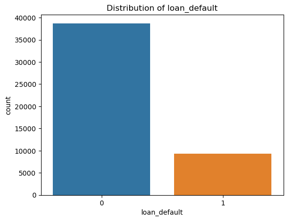

```python
sns.countplot(x='loan_default', data=train)
plt.title('Distribution of loan_default')
plt.show()
```

```python
var = pd.DataFrame(train.dtypes).reset_index()
var.columns = ['varname','dtype']
var['source'] = var['varname'].str[:2]
var.head()
```

|  | varname | dtype | source |
| --- | --- | --- | --- |
| 0 | Unnamed: 0.1 | int64 | Un |
| 1 | Unnamed: 0 | int64 | Un |
| 2 | id | int64 | id |
| 3 | loan_default | int64 | lo |
| 4 | AP001 | int64 | AP |

```python
var['source'].value_counts()
```

```
CD    36
TD    24
AP     9
CR     8
PA     6
Un     2
MB     2
id     1
lo     1
Name: source, dtype: int64
```

```python
# "AP004" is a bad data field and should be removed.
MB_list = list(var[var['source']=='MB']['varname'])
AP_list = list(var[(var['source']=='AP') & (var['varname']!='AP004')]['varname'])
TD_list = list(var[var['source']=='TD']['varname'])
CR_list = list(var[var['source']=='CR']['varname'])
PA_list = list(var[var['source']=='PA']['varname'])
CD_list = list(var[var['source']=='CD']['varname'])
AP_list
```

```
['AP001', 'AP002', 'AP003', 'AP005', 'AP006', 'AP007', 'AP008', 'AP009']
```

```python
train['loan_default'].value_counts(dropna=False)
```

```
0    38736
1     9264
Name: loan_default, dtype: int64
```

## Section 2: H2O Initialize

```python
#pip install h2o
```

```python
import h2o
h2o.init()
```

```
Checking whether there is an H2O instance running at http://localhost:54321..... not found.
Attempting to start a local H2O server...
  Java Version: java version "11.0.18" 2023-01-17 LTS; Java(TM) SE Runtime Environment 18.9 (build 11.0.18+9-LTS-195); Java HotSpot(TM) 64-Bit Server VM 18.9 (build 11.0.18+9-LTS-195, mixed mode)
  Starting server from /Users/jimac/opt/anaconda3/lib/python3.9/site-packages/h2o/backend/bin/h2o.jar
  Ice root: /var/folders/nj/2lz1zcjx46qc0b0_x0vsc8jc0000gn/T/tmpz2kilmoh
  JVM stdout: /var/folders/nj/2lz1zcjx46qc0b0_x0vsc8jc0000gn/T/tmpz2kilmoh/h2o_jimac_started_from_python.out
  JVM stderr: /var/folders/nj/2lz1zcjx46qc0b0_x0vsc8jc0000gn/T/tmpz2kilmoh/h2o_jimac_started_from_python.err
  Server is running at http://127.0.0.1:54321
Connecting to H2O server at http://127.0.0.1:54321 ... successful.
```

| H2O_cluster_uptime: | 03 secs |
| --- | --- |
| H2O_cluster_timezone: | America/New_York |
| H2O_data_parsing_timezone: | UTC |
| H2O_cluster_version: | 3.44.0.2 |
| H2O_cluster_version_age: | 11 days |
| H2O_cluster_name: | H2O_from_python_jimac_6djgr0 |
| H2O_cluster_total_nodes: | 1 |
| H2O_cluster_free_memory: | 2 Gb |
| H2O_cluster_total_cores: | 8 |
| H2O_cluster_allowed_cores: | 8 |
| H2O_cluster_status: | locked, healthy |
| H2O_connection_url: | http://127.0.0.1:54321 |
| H2O_connection_proxy: | {"http": null, "https": null} |
| H2O_internal_security: | False |
| Python_version: | 3.9.13 final |

```python
from h2o.estimators.gbm import H2OGradientBoostingEstimator
from h2o.estimators.random_forest import H2ORandomForestEstimator
```

## Section 3: Modeling - Random Forest

> - Small Sample Data

```python
target='loan_default'
```

> First, we only take 10% of our data to testing our model, if it's work well, we will continue using this model to train for all the data.

```python
train_smpl = train.sample(frac=0.1, random_state=123)
test_smpl = test.sample(frac=0.1, random_state=123)
train_hex = h2o.H2OFrame(train_smpl)
test_hex = h2o.H2OFrame(test_smpl)
```

```
Parse progress: |████████████████████████████████████████████████████████████████| (done) 100%
Parse progress: |████████████████████████████████████████████████████████████████| (done) 100%
```

```python
predictors = CR_list + TD_list + AP_list + MB_list + CR_list + PA_list
```

```python
rf_v1 = H2ORandomForestEstimator(
        model_id = 'rf_v1',
        ntrees = 500,
        nfolds=10,
        min_rows=100,
        seed=1234)
rf_v1.train(predictors,target,training_frame=train_hex)
```

```
drf Model Build progress: |
```

```
██████████████████████████████████████████████████████| (done) 100%
```

```
Model Details
=============
H2ORandomForestEstimator : Distributed Random Forest
Model Key: rf_v1
```

Model Summary:

|  | number_of_trees | number_of_internal_trees | model_size_in_bytes | min_depth | max_depth | mean_depth | min_leaves | max_leaves | mean_leaves |
| --- | --- | --- | --- | --- | --- | --- | --- | --- | --- |
|  | 500.0 | 500.0 | 182557.0 | 6.0 | 11.0 | 8.01 | 19.0 | 26.0 | 22.65 |

```
ModelMetricsRegression: drf
** Reported on train data. **

MSE: 0.1482689105480556
RMSE: 0.3850570224629796
MAE: 0.2980819930628699
RMSLE: 0.2699407348893302
Mean Residual Deviance: 0.1482689105480556
```

```
ModelMetricsRegression: drf
** Reported on cross-validation data. **

MSE: 0.14855042632252774
RMSE: 0.3854223998712682
MAE: 0.29840545587069994
RMSLE: 0.2701903434433483
Mean Residual Deviance: 0.14855042632252774
```

Cross-Validation Metrics Summary:

|  | mean | sd | cv_1_valid | cv_2_valid | cv_3_valid | cv_4_valid | cv_5_valid | cv_6_valid | cv_7_valid | cv_8_valid | cv_9_valid | cv_10_valid |
| --- | --- | --- | --- | --- | --- | --- | --- | --- | --- | --- | --- | --- |
| mae | 0.2983556 | 0.0090298 | 0.3168004 | 0.2979554 | 0.3109951 | 0.2966296 | 0.3011847 | 0.2937843 | 0.2887560 | 0.2904476 | 0.2933975 | 0.2936053 |
| mean_residual_deviance | 0.1484421 | 0.0107364 | 0.1715983 | 0.1494880 | 0.1622000 | 0.1456810 | 0.1502231 | 0.1450631 | 0.1386210 | 0.1394313 | 0.1420383 | 0.1400768 |
| mse | 0.1484421 | 0.0107364 | 0.1715983 | 0.1494880 | 0.1622000 | 0.1456810 | 0.1502231 | 0.1450631 | 0.1386210 | 0.1394313 | 0.1420383 | 0.1400768 |
| r2 | 0.0302111 | 0.0106292 | 0.0299224 | 0.0466097 | 0.0205418 | 0.0467004 | 0.0325119 | 0.0154112 | 0.0298076 | 0.0207130 | 0.0357592 | 0.0241335 |
| residual_deviance | 0.1484421 | 0.0107364 | 0.1715983 | 0.1494880 | 0.1622000 | 0.1456810 | 0.1502231 | 0.1450631 | 0.1386210 | 0.1394313 | 0.1420383 | 0.1400768 |
| rmse | 0.3850632 | 0.0136777 | 0.4142442 | 0.3866367 | 0.4027406 | 0.3816818 | 0.3875863 | 0.3808715 | 0.3723184 | 0.3734050 | 0.3768797 | 0.3742684 |
| rmsle | 0.2700461 | 0.0070809 | 0.2847346 | 0.2697644 | 0.2800803 | 0.2674985 | 0.2716484 | 0.2683961 | 0.2630747 | 0.2644593 | 0.2654973 | 0.2653074 |

Scoring History:

|  | timestamp | duration | number_of_trees | training_rmse | training_mae | training_deviance |
| --- | --- | --- | --- | --- | --- | --- |
|  | 2023-11-19 20:52:13 | 35.641 sec | 0.0 | nan | nan | nan |
|  | 2023-11-19 20:52:13 | 35.668 sec | 1.0 | 0.3951020 | 0.2964363 | 0.1561056 |
|  | 2023-11-19 20:52:13 | 35.692 sec | 2.0 | 0.3934936 | 0.2961200 | 0.1548372 |
|  | 2023-11-19 20:52:13 | 35.735 sec | 3.0 | 0.3906026 | 0.2971942 | 0.1525704 |
|  | 2023-11-19 20:52:13 | 35.761 sec | 4.0 | 0.3909273 | 0.2982658 | 0.1528242 |
|  | 2023-11-19 20:52:13 | 35.780 sec | 5.0 | 0.3912353 | 0.2988889 | 0.1530651 |
|  | 2023-11-19 20:52:13 | 35.790 sec | 6.0 | 0.3900785 | 0.2988183 | 0.1521613 |
|  | 2023-11-19 20:52:13 | 35.799 sec | 7.0 | 0.3886503 | 0.2983202 | 0.1510491 |
|  | 2023-11-19 20:52:13 | 35.808 sec | 8.0 | 0.3887074 | 0.2983383 | 0.1510935 |
|  | 2023-11-19 20:52:13 | 35.818 sec | 9.0 | 0.3878163 | 0.2979263 | 0.1504015 |
| --- | --- | --- | --- | --- | --- | --- |
|  | 2023-11-19 20:52:17 | 39.278 sec | 491.0 | 0.3850643 | 0.2980897 | 0.1482745 |
|  | 2023-11-19 20:52:17 | 39.286 sec | 492.0 | 0.3850682 | 0.2981061 | 0.1482775 |
|  | 2023-11-19 20:52:17 | 39.293 sec | 493.0 | 0.3850753 | 0.2981115 | 0.1482830 |
|  | 2023-11-19 20:52:17 | 39.301 sec | 494.0 | 0.3850718 | 0.2981161 | 0.1482803 |
|  | 2023-11-19 20:52:17 | 39.309 sec | 495.0 | 0.3850704 | 0.2981062 | 0.1482792 |
|  | 2023-11-19 20:52:17 | 39.317 sec | 496.0 | 0.3850642 | 0.2980966 | 0.1482744 |
|  | 2023-11-19 20:52:17 | 39.324 sec | 497.0 | 0.3850632 | 0.2980936 | 0.1482736 |
|  | 2023-11-19 20:52:17 | 39.332 sec | 498.0 | 0.3850581 | 0.2980800 | 0.1482697 |
|  | 2023-11-19 20:52:17 | 39.340 sec | 499.0 | 0.3850558 | 0.2980838 | 0.1482680 |
|  | 2023-11-19 20:52:17 | 39.348 sec | 500.0 | 0.3850570 | 0.2980820 | 0.1482689 |

```
[501 rows x 7 columns]
```

Variable Importances:

| variable | relative_importance | scaled_importance | percentage |
| --- | --- | --- | --- |
| MB007 | 2862.6928711 | 1.0 | 0.1941703 |
| TD013 | 2585.8332520 | 0.9032870 | 0.1753915 |
| AP003 | 1427.7395020 | 0.4987400 | 0.0968405 |
| TD009 | 1345.4895020 | 0.4700083 | 0.0912617 |
| CR015 | 877.7077026 | 0.3066021 | 0.0595330 |
| TD005 | 812.1909180 | 0.2837157 | 0.0550892 |
| CR009 | 581.4403076 | 0.2031096 | 0.0394378 |
| TD014 | 404.8521118 | 0.1414235 | 0.0274602 |
| AP008 | 311.5442505 | 0.1088291 | 0.0211314 |
| CR017 | 282.7981873 | 0.0987875 | 0.0191816 |
| --- | --- | --- | --- |
| TD015 | 53.6095695 | 0.0187270 | 0.0036362 |
| TD002 | 45.1937370 | 0.0157871 | 0.0030654 |
| CR005 | 38.9313202 | 0.0135995 | 0.0026406 |
| PA030 | 11.9053154 | 0.0041588 | 0.0008075 |
| TD025 | 0.0 | 0.0 | 0.0 |
| TD026 | 0.0 | 0.0 | 0.0 |
| TD027 | 0.0 | 0.0 | 0.0 |
| TD028 | 0.0 | 0.0 | 0.0 |
| TD029 | 0.0 | 0.0 | 0.0 |
| TD054 | 0.0 | 0.0 | 0.0 |

```
[40 rows x 4 columns]
```

```
[tips]
Use `model.explain()` to inspect the model.
--
Use `h2o.display.toggle_user_tips()` to switch on/off this section.
```

> Create a function to visulize variable importance

```python
def VarImp(model_name):

    from sklearn.metrics import roc_curve,auc
    from sklearn.metrics import average_precision_score
    from sklearn.metrics import precision_recall_curve
    import matplotlib.pyplot as plt

    # plot the variable importance
    plt.rcdefaults()
    variables = model_name._model_json['output']['variable_importances']['variable']
    y_pos = np.arange(len(variables))
    fig, ax = plt.subplots(figsize = (6,len(variables)/2))
    scaled_importance = model_name._model_json['output']['variable_importances']['scaled_importance']
    ax.barh(y_pos,scaled_importance,align='center',color='green')
    ax.set_yticks(y_pos)
    ax.set_yticklabels(variables)
    ax.invert_yaxis()
    ax.set_xlabel('Scaled Importance')
    ax.set_title('Variable Importance')
    plt.show()
```

> Top 10 `variable_importances`

```python
variable_importances = rf_v1._model_json['output']['variable_importances']['variable'][:10]
scaled_importances = rf_v1._model_json['output']['variable_importances']['scaled_importance'][:10]

# Print the top 10 variable importances along with their scaled importances
for i, (importance, scaled_importance) in enumerate(zip(variable_importances, scaled_importances), start=1):
    print(f"Rank {i}: Variable Importance: {importance}, Scaled Importance: {scaled_importance:.3f}")
```

```
Rank 1: Variable Importance: MB007, Scaled Importance: 1.000
Rank 2: Variable Importance: TD013, Scaled Importance: 0.903
Rank 3: Variable Importance: AP003, Scaled Importance: 0.499
Rank 4: Variable Importance: TD009, Scaled Importance: 0.470
Rank 5: Variable Importance: CR015, Scaled Importance: 0.307
Rank 6: Variable Importance: TD005, Scaled Importance: 0.284
Rank 7: Variable Importance: CR009, Scaled Importance: 0.203
Rank 8: Variable Importance: TD014, Scaled Importance: 0.141
Rank 9: Variable Importance: AP008, Scaled Importance: 0.109
Rank 10: Variable Importance: CR017, Scaled Importance: 0.099
```

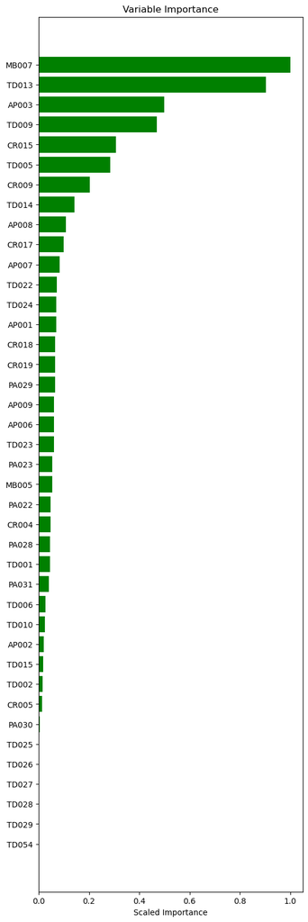

```python
VarImp(rf_v1)
```

```python
predictions = rf_v1.predict(test_hex)
predictions.head()
test_scores = test_hex['loan_default'].cbind(predictions).as_data_frame()
test_scores.head()
```

```
drf prediction progress: |███████████████████████████████████████████████████████| (done) 100%
```

|  | loan_default | predict |
| --- | --- | --- |
| 0 | 0 | 0.293295 |
| 1 | 0 | 0.093927 |
| 2 | 0 | 0.156704 |
| 3 | 0 | 0.307440 |
| 4 | 0 | 0.145171 |

> Define a `createGains` Function, for repetition purpose of generate the gain table

```python
def createGains(model):
    predictions = model.predict(test_hex)
    test_scores = test_hex['loan_default'].cbind(predictions).as_data_frame()

    #sort on prediction (descending), add id, and decile for groups containing 1/10 of datapoints
    test_scores = test_scores.sort_values(by='predict',ascending=False)
    test_scores['row_id'] = range(0,0+len(test_scores))
    test_scores['decile'] = ( test_scores['row_id'] / (len(test_scores)/10) ).astype(int)
    #see count by decile
    test_scores.loc[test_scores['decile'] == 10]=9
    test_scores['decile'].value_counts()

    #create gains table
    gains = test_scores.groupby('decile')['loan_default'].agg(['count','sum'])
    gains.columns = ['count','actual']
    gains

    #add features to gains table
    gains['non_actual'] = gains['count'] - gains['actual']
    gains['cum_count'] = gains['count'].cumsum()
    gains['cum_actual'] = gains['actual'].cumsum()
    gains['cum_non_actual'] = gains['non_actual'].cumsum()
    gains['percent_cum_actual'] = (gains['cum_actual'] / np.max(gains['cum_actual'])).round(2)
    gains['percent_cum_non_actual'] = (gains['cum_non_actual'] / np.max(gains['cum_non_actual'])).round(2)
    gains['if_random'] = np.max(gains['cum_actual']) /10
    gains['if_random'] = gains['if_random'].cumsum()
    gains['lift'] = (gains['cum_actual'] / gains['if_random']).round(2)
    gains['K_S'] = np.abs( gains['percent_cum_actual'] -  gains['percent_cum_non_actual'] ) * 100
    gains['gain']=(gains['cum_actual']/gains['cum_count']*100).round(2)
    gains = pd.DataFrame(gains)
    return(gains)
```

```python
createGains(rf_v1)
```

```
drf prediction progress: |███████████████████████████████████████████████████████| (done) 100%
```

| decile | count | actual | non_actual | cum_count | cum_actual | cum_non_actual | percent_cum_actual | percent_cum_non_actual | if_random | lift | K_S | gain |
| --- | --- | --- | --- | --- | --- | --- | --- | --- | --- | --- | --- | --- |
| 0 | 320 | 107 | 213 | 320 | 107 | 213 | 0.17 | 0.08 | 61.8 | 1.73 | 9.0 | 33.44 |
| 1 | 320 | 88 | 232 | 640 | 195 | 445 | 0.32 | 0.17 | 123.6 | 1.58 | 15.0 | 30.47 |
| 2 | 320 | 82 | 238 | 960 | 277 | 683 | 0.45 | 0.26 | 185.4 | 1.49 | 19.0 | 28.85 |
| 3 | 320 | 64 | 256 | 1280 | 341 | 939 | 0.55 | 0.36 | 247.2 | 1.38 | 19.0 | 26.64 |
| 4 | 320 | 60 | 260 | 1600 | 401 | 1199 | 0.65 | 0.46 | 309.0 | 1.30 | 19.0 | 25.06 |
| 5 | 320 | 53 | 267 | 1920 | 454 | 1466 | 0.73 | 0.57 | 370.8 | 1.22 | 16.0 | 23.65 |
| 6 | 320 | 46 | 274 | 2240 | 500 | 1740 | 0.81 | 0.67 | 432.6 | 1.16 | 14.0 | 22.32 |
| 7 | 320 | 50 | 270 | 2560 | 550 | 2010 | 0.89 | 0.78 | 494.4 | 1.11 | 11.0 | 21.48 |
| 8 | 320 | 41 | 279 | 2880 | 591 | 2289 | 0.96 | 0.89 | 556.2 | 1.06 | 7.0 | 20.52 |
| 9 | 320 | 27 | 293 | 3200 | 618 | 2582 | 1.00 | 1.00 | 618.0 | 1.00 | 0.0 | 19.31 |

> Define the `ROC_AUC` Function to plot the Roc Curve

```python
def ROC_AUC(my_result,df,target):
    from sklearn.metrics import roc_curve,auc
    from sklearn.metrics import average_precision_score
    from sklearn.metrics import precision_recall_curve
    import matplotlib.pyplot as plt

    # ROC
    y_actual = df[target].as_data_frame()
    y_pred = my_result.predict(df).as_data_frame()
    fpr = list()
    tpr = list()
    roc_auc = list()
    fpr,tpr,_ = roc_curve(y_actual,y_pred)
    roc_auc = auc(fpr,tpr)

    # Precision-Recall
    average_precision = average_precision_score(y_actual,y_pred)

    print('')
    print('   * ROC curve: The ROC curve plots the true positive rate vs. the false rositive sate')
    print('')
    print('   * The area under the curve (AUC): A value between 0.5 (random) and 1.0 (perfect), measuring the prediction accuracy')
    print('')
    print('   * Recall (R) = The number of true positives / (the number of true positives + the number of false negatives)')
    print('')

    # plotting
    plt.figure(figsize=(10,4))

    # ROC
    plt.subplot(1,2,1)
    plt.plot(fpr,tpr,color='darkorange',lw=2,label='ROC curve (aare=%0.2f)' % roc_auc)
    plt.plot([0,1],[0,1],color='navy',lw=3,linestyle='--')
    plt.xlim([0.0,1.0])
    plt.ylim([0.0,1.05])
    plt.xlabel('False Positive Rate')
    plt.ylabel('True Positive Rate')
    plt.title('Receiver operating characteristic: AUC={0:0.4f}'.format(roc_auc))
    plt.legend(loc='lower right')

    # Precision-Recall
    plt.subplot(1,2,2)
    precision,recall,_ = precision_recall_curve(y_actual,y_pred)
    plt.step(recall,precision,color='b',alpha=0.2,where='post')
    plt.fill_between(recall,precision,step='post',alpha=0.2,color='b')
    plt.xlabel('Recall')
    plt.ylabel('Precision')
    plt.ylim([0.0,1.05])
    plt.xlim([0.0,1.0])
    plt.title('Precision-Recall curve: PR={0:0.4f}'.format(average_precision))
    plt.show()
```

```
drf prediction progress: |███████████████████████████████████████████████████████| (done) 100%

   * ROC curve: The ROC curve plots the true positive rate vs. the false rositive sate

   * The area under the curve (AUC): A value between 0.5 (random) and 1.0 (perfect), measuring the prediction accuracy

   * Recall (R) = The number of true positives / (the number of true positives + the number of false negatives)
```

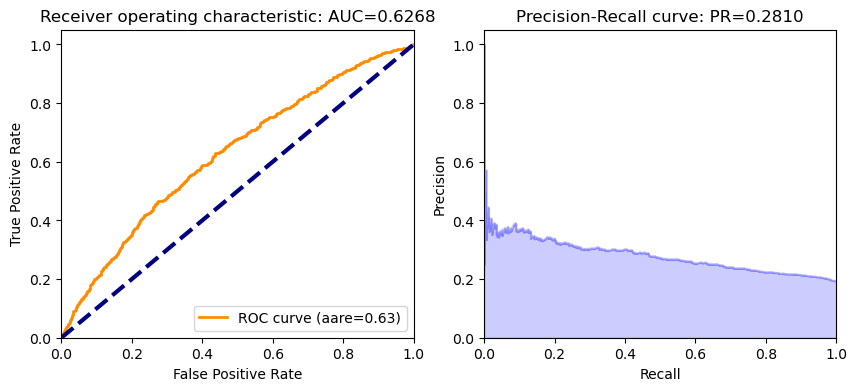

```python
ROC_AUC(rf_v1,test_hex,'loan_default')
```

> - Entire Data

```python
train_hex = h2o.H2OFrame(train)
test_hex = h2o.H2OFrame(test)
```

```
Parse progress: |████████████████████████████████████████████████████████████████| (done) 100%
Parse progress: |████████████████████████████████████████████████████████████████| (done) 100%
```

```python
rf_v2 = H2ORandomForestEstimator(
        model_id = 'rf_v2',
        ntrees = 500,
        nfolds=10,
        min_rows=100,
        seed=1234)
rf_v2.train(predictors,target,training_frame=train_hex)
```

```
drf Model Build progress: |
```

```
██████████████████████████████████████████████████████| (done) 100%
```

```
Model Details
=============
H2ORandomForestEstimator : Distributed Random Forest
Model Key: rf_v2
```

Model Summary:

|  | number_of_trees | number_of_internal_trees | model_size_in_bytes | min_depth | max_depth | mean_depth | min_leaves | max_leaves | mean_leaves |
| --- | --- | --- | --- | --- | --- | --- | --- | --- | --- |
|  | 500.0 | 500.0 | 1602810.0 | 12.0 | 19.0 | 15.036 | 212.0 | 237.0 | 225.304 |

```
ModelMetricsRegression: drf
** Reported on train data. **

MSE: 0.14799549883646565
RMSE: 0.384701831080209
MAE: 0.2971329020742607
RMSLE: 0.26967645319898575
Mean Residual Deviance: 0.14799549883646565
```

```
ModelMetricsRegression: drf
** Reported on cross-validation data. **

MSE: 0.14806588509607715
RMSE: 0.3847933017817191
MAE: 0.2973333862203327
RMSLE: 0.2697443976509279
Mean Residual Deviance: 0.14806588509607715
```

Cross-Validation Metrics Summary:

|  | mean | sd | cv_1_valid | cv_2_valid | cv_3_valid | cv_4_valid | cv_5_valid | cv_6_valid | cv_7_valid | cv_8_valid | cv_9_valid | cv_10_valid |
| --- | --- | --- | --- | --- | --- | --- | --- | --- | --- | --- | --- | --- |
| mae | 0.2973324 | 0.0037954 | 0.2960088 | 0.2945631 | 0.2996778 | 0.3017406 | 0.2997360 | 0.2898218 | 0.2943509 | 0.3016776 | 0.2994150 | 0.2963326 |
| mean_residual_deviance | 0.1480645 | 0.0040083 | 0.1456903 | 0.1448206 | 0.1506940 | 0.1523702 | 0.1517528 | 0.1413143 | 0.1437931 | 0.1522907 | 0.1507074 | 0.1472116 |
| mse | 0.1480645 | 0.0040083 | 0.1456903 | 0.1448206 | 0.1506940 | 0.1523702 | 0.1517528 | 0.1413143 | 0.1437931 | 0.1522907 | 0.1507074 | 0.1472116 |
| r2 | 0.0491040 | 0.0064043 | 0.0551177 | 0.0459176 | 0.0550708 | 0.0557202 | 0.0408433 | 0.0557050 | 0.0463726 | 0.0433132 | 0.0402860 | 0.0526932 |
| residual_deviance | 0.1480645 | 0.0040083 | 0.1456903 | 0.1448206 | 0.1506940 | 0.1523702 | 0.1517528 | 0.1413143 | 0.1437931 | 0.1522907 | 0.1507074 | 0.1472116 |
| rmse | 0.3847596 | 0.0052209 | 0.381694 | 0.3805530 | 0.3881933 | 0.3903463 | 0.3895546 | 0.3759179 | 0.3792006 | 0.3902444 | 0.3882105 | 0.3836816 |
| rmsle | 0.2697309 | 0.0028996 | 0.2680479 | 0.2676490 | 0.2711158 | 0.2723407 | 0.2725845 | 0.2643347 | 0.2671998 | 0.2729181 | 0.2720714 | 0.2690470 |

Scoring History:

|  | timestamp | duration | number_of_trees | training_rmse | training_mae | training_deviance |
| --- | --- | --- | --- | --- | --- | --- |
|  | 2023-11-19 20:56:34 | 4 min 8.007 sec | 0.0 | nan | nan | nan |
|  | 2023-11-19 20:56:34 | 4 min 8.047 sec | 1.0 | 0.3917139 | 0.2959442 | 0.1534398 |
|  | 2023-11-19 20:56:34 | 4 min 8.089 sec | 2.0 | 0.3902091 | 0.2960623 | 0.1522632 |
|  | 2023-11-19 20:56:34 | 4 min 8.130 sec | 3.0 | 0.3891379 | 0.2963517 | 0.1514283 |
|  | 2023-11-19 20:56:34 | 4 min 8.169 sec | 4.0 | 0.3886475 | 0.2964842 | 0.1510469 |
|  | 2023-11-19 20:56:34 | 4 min 8.211 sec | 5.0 | 0.3886758 | 0.2970454 | 0.1510688 |
|  | 2023-11-19 20:56:34 | 4 min 8.255 sec | 6.0 | 0.3880645 | 0.2967851 | 0.1505941 |
|  | 2023-11-19 20:56:34 | 4 min 8.295 sec | 7.0 | 0.3875679 | 0.2967011 | 0.1502089 |
|  | 2023-11-19 20:56:34 | 4 min 8.338 sec | 8.0 | 0.3874794 | 0.2969617 | 0.1501403 |
|  | 2023-11-19 20:56:35 | 4 min 8.378 sec | 9.0 | 0.3874264 | 0.2972392 | 0.1500992 |
| --- | --- | --- | --- | --- | --- | --- |
|  | 2023-11-19 20:56:38 | 4 min 11.799 sec | 83.0 | 0.3848899 | 0.2971195 | 0.1481403 |
|  | 2023-11-19 20:56:38 | 4 min 11.849 sec | 84.0 | 0.3848760 | 0.2971109 | 0.1481295 |
|  | 2023-11-19 20:56:38 | 4 min 11.893 sec | 85.0 | 0.3848889 | 0.2971130 | 0.1481394 |
|  | 2023-11-19 20:56:38 | 4 min 11.938 sec | 86.0 | 0.3848840 | 0.2971362 | 0.1481357 |
|  | 2023-11-19 20:56:38 | 4 min 11.975 sec | 87.0 | 0.3848847 | 0.2971094 | 0.1481362 |
|  | 2023-11-19 20:56:42 | 4 min 16.005 sec | 191.0 | 0.3847418 | 0.2971489 | 0.1480262 |
|  | 2023-11-19 20:56:46 | 4 min 20.027 sec | 291.0 | 0.3847445 | 0.2971098 | 0.1480284 |
|  | 2023-11-19 20:56:50 | 4 min 24.040 sec | 391.0 | 0.3847217 | 0.2971162 | 0.1480108 |
|  | 2023-11-19 20:56:54 | 4 min 28.047 sec | 493.0 | 0.3847013 | 0.2971226 | 0.1479951 |
|  | 2023-11-19 20:56:54 | 4 min 28.320 sec | 500.0 | 0.3847018 | 0.2971329 | 0.1479955 |

```
[93 rows x 7 columns]
```

Variable Importances:

| variable | relative_importance | scaled_importance | percentage |
| --- | --- | --- | --- |
| TD013 | 29439.9609375 | 1.0 | 0.1540494 |
| AP003 | 24723.1289062 | 0.8397813 | 0.1293678 |
| TD009 | 20941.1621094 | 0.7113176 | 0.1095780 |
| MB007 | 20625.0996094 | 0.7005818 | 0.1079242 |
| TD005 | 13444.1943359 | 0.4566648 | 0.0703489 |
| CR015 | 9182.4257812 | 0.3119035 | 0.0480485 |
| TD014 | 7513.6225586 | 0.2552185 | 0.0393162 |
| TD010 | 4632.1586914 | 0.1573426 | 0.0242385 |
| MB005 | 4442.7133789 | 0.1509076 | 0.0232472 |
| AP001 | 3982.3588867 | 0.1352705 | 0.0208383 |
| --- | --- | --- | --- |
| TD027 | 0.0 | 0.0 | 0.0 |
| TD028 | 0.0 | 0.0 | 0.0 |
| TD029 | 0.0 | 0.0 | 0.0 |
| TD044 | 0.0 | 0.0 | 0.0 |
| TD048 | 0.0 | 0.0 | 0.0 |
| TD051 | 0.0 | 0.0 | 0.0 |
| TD054 | 0.0 | 0.0 | 0.0 |
| TD055 | 0.0 | 0.0 | 0.0 |
| TD061 | 0.0 | 0.0 | 0.0 |
| TD062 | 0.0 | 0.0 | 0.0 |

```
[46 rows x 4 columns]
```

```
[tips]
Use `model.explain()` to inspect the model.
--
Use `h2o.display.toggle_user_tips()` to switch on/off this section.
```

> Top 10 `variable_importances`

```python
variable_importances = rf_v2._model_json['output']['variable_importances']['variable'][:10]
scaled_importances = rf_v2._model_json['output']['variable_importances']['scaled_importance'][:10]

# Print the top 10 variable importances along with their scaled importances
for i, (importance, scaled_importance) in enumerate(zip(variable_importances, scaled_importances), start=1):
    print(f"Rank {i}: Variable Importance: {importance}, Scaled Importance: {scaled_importance:.3f}")
```

```
Rank 1: Variable Importance: TD013, Scaled Importance: 1.000
Rank 2: Variable Importance: AP003, Scaled Importance: 0.840
Rank 3: Variable Importance: TD009, Scaled Importance: 0.711
Rank 4: Variable Importance: MB007, Scaled Importance: 0.701
Rank 5: Variable Importance: TD005, Scaled Importance: 0.457
Rank 6: Variable Importance: CR015, Scaled Importance: 0.312
Rank 7: Variable Importance: TD014, Scaled Importance: 0.255
Rank 8: Variable Importance: TD010, Scaled Importance: 0.157
Rank 9: Variable Importance: MB005, Scaled Importance: 0.151
Rank 10: Variable Importance: AP001, Scaled Importance: 0.135
```

```python
createGains(rf_v2)
```

```
drf prediction progress: |███████████████████████████████████████████████████████| (done) 100%
```

| decile | count | actual | non_actual | cum_count | cum_actual | cum_non_actual | percent_cum_actual | percent_cum_non_actual | if_random | lift | K_S | gain |
| --- | --- | --- | --- | --- | --- | --- | --- | --- | --- | --- | --- | --- |
| 0 | 3200 | 1203 | 1997 | 3200 | 1203 | 1997 | 0.19 | 0.08 | 622.4 | 1.93 | 11.0 | 37.59 |
| 1 | 3200 | 948 | 2252 | 6400 | 2151 | 4249 | 0.35 | 0.16 | 1244.8 | 1.73 | 19.0 | 33.61 |
| 2 | 3200 | 748 | 2452 | 9600 | 2899 | 6701 | 0.47 | 0.26 | 1867.2 | 1.55 | 21.0 | 30.20 |
| 3 | 3200 | 731 | 2469 | 12800 | 3630 | 9170 | 0.58 | 0.36 | 2489.6 | 1.46 | 22.0 | 28.36 |
| 4 | 3200 | 642 | 2558 | 16000 | 4272 | 11728 | 0.69 | 0.45 | 3112.0 | 1.37 | 24.0 | 26.70 |
| 5 | 3200 | 535 | 2665 | 19200 | 4807 | 14393 | 0.77 | 0.56 | 3734.4 | 1.29 | 21.0 | 25.04 |
| 6 | 3200 | 461 | 2739 | 22400 | 5268 | 17132 | 0.85 | 0.66 | 4356.8 | 1.21 | 19.0 | 23.52 |
| 7 | 3200 | 413 | 2787 | 25600 | 5681 | 19919 | 0.91 | 0.77 | 4979.2 | 1.14 | 14.0 | 22.19 |
| 8 | 3200 | 329 | 2871 | 28800 | 6010 | 22790 | 0.97 | 0.88 | 5601.6 | 1.07 | 9.0 | 20.87 |
| 9 | 3200 | 214 | 2986 | 32000 | 6224 | 25776 | 1.00 | 1.00 | 6224.0 | 1.00 | 0.0 | 19.45 |

```
drf prediction progress: |███████████████████████████████████████████████████████| (done) 100%

   * ROC curve: The ROC curve plots the true positive rate vs. the false rositive sate

   * The area under the curve (AUC): A value between 0.5 (random) and 1.0 (perfect), measuring the prediction accuracy

   * Recall (R) = The number of true positives / (the number of true positives + the number of false negatives)
```

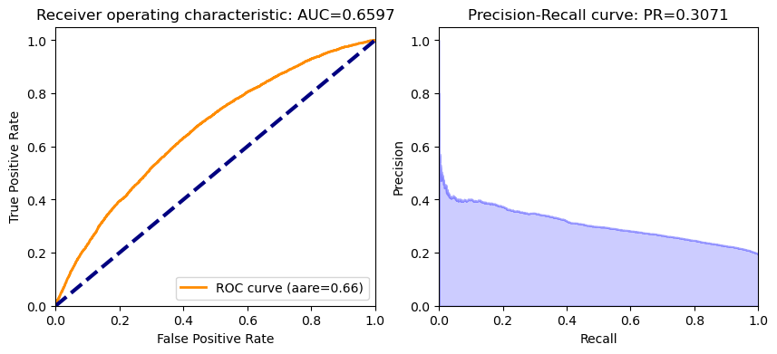

```python
ROC_AUC(rf_v2,test_hex,'loan_default')
```

> - Use H2O's `balance_classes`

```python
rf_v3 = H2ORandomForestEstimator(
        model_id = 'rf_v3',
        ntrees = 500,
        nfolds=10,
        min_rows=100,
        balance_classes = True,
        seed=1234)
rf_v3.train(predictors,target,training_frame=train_hex)
```

```
drf Model Build progress: |
```

```
██████████████████████████████████████████████████████| (done) 100%
```

```
Model Details
=============
H2ORandomForestEstimator : Distributed Random Forest
Model Key: rf_v3
```

Model Summary:

|  | number_of_trees | number_of_internal_trees | model_size_in_bytes | min_depth | max_depth | mean_depth | min_leaves | max_leaves | mean_leaves |
| --- | --- | --- | --- | --- | --- | --- | --- | --- | --- |
|  | 500.0 | 500.0 | 1602804.0 | 12.0 | 19.0 | 15.036 | 212.0 | 237.0 | 225.304 |

```
ModelMetricsRegression: drf
** Reported on train data. **

MSE: 0.14799549883646565
RMSE: 0.384701831080209
MAE: 0.2971329020742607
RMSLE: 0.26967645319898575
Mean Residual Deviance: 0.14799549883646565
```

```
ModelMetricsRegression: drf
** Reported on cross-validation data. **

MSE: 0.14806588509607715
RMSE: 0.3847933017817191
MAE: 0.2973333862203327
RMSLE: 0.2697443976509279
Mean Residual Deviance: 0.14806588509607715
```

Cross-Validation Metrics Summary:

|  | mean | sd | cv_1_valid | cv_2_valid | cv_3_valid | cv_4_valid | cv_5_valid | cv_6_valid | cv_7_valid | cv_8_valid | cv_9_valid | cv_10_valid |
| --- | --- | --- | --- | --- | --- | --- | --- | --- | --- | --- | --- | --- |
| mae | 0.2973324 | 0.0037954 | 0.2960088 | 0.2945631 | 0.2996778 | 0.3017406 | 0.2997360 | 0.2898218 | 0.2943509 | 0.3016776 | 0.2994150 | 0.2963326 |
| mean_residual_deviance | 0.1480645 | 0.0040083 | 0.1456903 | 0.1448206 | 0.1506940 | 0.1523702 | 0.1517528 | 0.1413143 | 0.1437931 | 0.1522907 | 0.1507074 | 0.1472116 |
| mse | 0.1480645 | 0.0040083 | 0.1456903 | 0.1448206 | 0.1506940 | 0.1523702 | 0.1517528 | 0.1413143 | 0.1437931 | 0.1522907 | 0.1507074 | 0.1472116 |
| r2 | 0.0491040 | 0.0064043 | 0.0551177 | 0.0459176 | 0.0550708 | 0.0557202 | 0.0408433 | 0.0557050 | 0.0463726 | 0.0433132 | 0.0402860 | 0.0526932 |
| residual_deviance | 0.1480645 | 0.0040083 | 0.1456903 | 0.1448206 | 0.1506940 | 0.1523702 | 0.1517528 | 0.1413143 | 0.1437931 | 0.1522907 | 0.1507074 | 0.1472116 |
| rmse | 0.3847596 | 0.0052209 | 0.381694 | 0.3805530 | 0.3881933 | 0.3903463 | 0.3895546 | 0.3759179 | 0.3792006 | 0.3902444 | 0.3882105 | 0.3836816 |
| rmsle | 0.2697309 | 0.0028996 | 0.2680479 | 0.2676490 | 0.2711158 | 0.2723407 | 0.2725845 | 0.2643347 | 0.2671998 | 0.2729181 | 0.2720714 | 0.2690470 |

Scoring History:

|  | timestamp | duration | number_of_trees | training_rmse | training_mae | training_deviance |
| --- | --- | --- | --- | --- | --- | --- |
|  | 2023-11-19 21:00:52 | 3 min 51.652 sec | 0.0 | nan | nan | nan |
|  | 2023-11-19 21:00:52 | 3 min 51.699 sec | 1.0 | 0.3917139 | 0.2959442 | 0.1534398 |
|  | 2023-11-19 21:00:52 | 3 min 51.746 sec | 2.0 | 0.3902091 | 0.2960623 | 0.1522632 |
|  | 2023-11-19 21:00:52 | 3 min 51.786 sec | 3.0 | 0.3891379 | 0.2963517 | 0.1514283 |
|  | 2023-11-19 21:00:52 | 3 min 51.825 sec | 4.0 | 0.3886475 | 0.2964842 | 0.1510469 |
|  | 2023-11-19 21:00:52 | 3 min 51.867 sec | 5.0 | 0.3886758 | 0.2970454 | 0.1510688 |
|  | 2023-11-19 21:00:52 | 3 min 51.921 sec | 6.0 | 0.3880645 | 0.2967851 | 0.1505941 |
|  | 2023-11-19 21:00:52 | 3 min 51.975 sec | 7.0 | 0.3875679 | 0.2967011 | 0.1502089 |
|  | 2023-11-19 21:00:52 | 3 min 52.020 sec | 8.0 | 0.3874794 | 0.2969617 | 0.1501403 |
|  | 2023-11-19 21:00:52 | 3 min 52.065 sec | 9.0 | 0.3874264 | 0.2972392 | 0.1500992 |
| --- | --- | --- | --- | --- | --- | --- |
|  | 2023-11-19 21:00:56 | 3 min 55.493 sec | 89.0 | 0.3848560 | 0.2970807 | 0.1481141 |
|  | 2023-11-19 21:00:56 | 3 min 55.534 sec | 90.0 | 0.3848521 | 0.2970840 | 0.1481112 |
|  | 2023-11-19 21:00:56 | 3 min 55.573 sec | 91.0 | 0.3848561 | 0.2970993 | 0.1481142 |
|  | 2023-11-19 21:00:56 | 3 min 55.613 sec | 92.0 | 0.3848531 | 0.2970876 | 0.1481119 |
|  | 2023-11-19 21:00:56 | 3 min 55.651 sec | 93.0 | 0.3848597 | 0.2970912 | 0.1481170 |
|  | 2023-11-19 21:01:00 | 3 min 59.668 sec | 197.0 | 0.3847465 | 0.2971502 | 0.1480299 |
|  | 2023-11-19 21:01:04 | 4 min 3.687 sec | 254.0 | 0.3847448 | 0.2971448 | 0.1480285 |
|  | 2023-11-19 21:01:08 | 4 min 7.694 sec | 350.0 | 0.3847160 | 0.2970859 | 0.1480064 |
|  | 2023-11-19 21:01:12 | 4 min 11.710 sec | 448.0 | 0.3847069 | 0.2970930 | 0.1479994 |
|  | 2023-11-19 21:01:14 | 4 min 14.030 sec | 500.0 | 0.3847018 | 0.2971329 | 0.1479955 |

```
[99 rows x 7 columns]
```

Variable Importances:

| variable | relative_importance | scaled_importance | percentage |
| --- | --- | --- | --- |
| TD013 | 29439.9609375 | 1.0 | 0.1540494 |
| AP003 | 24723.1289062 | 0.8397813 | 0.1293678 |
| TD009 | 20941.1621094 | 0.7113176 | 0.1095780 |
| MB007 | 20625.0996094 | 0.7005818 | 0.1079242 |
| TD005 | 13444.1943359 | 0.4566648 | 0.0703489 |
| CR015 | 9182.4257812 | 0.3119035 | 0.0480485 |
| TD014 | 7513.6225586 | 0.2552185 | 0.0393162 |
| TD010 | 4632.1586914 | 0.1573426 | 0.0242385 |
| MB005 | 4442.7133789 | 0.1509076 | 0.0232472 |
| AP001 | 3982.3588867 | 0.1352705 | 0.0208383 |
| --- | --- | --- | --- |
| TD027 | 0.0 | 0.0 | 0.0 |
| TD028 | 0.0 | 0.0 | 0.0 |
| TD029 | 0.0 | 0.0 | 0.0 |
| TD044 | 0.0 | 0.0 | 0.0 |
| TD048 | 0.0 | 0.0 | 0.0 |
| TD051 | 0.0 | 0.0 | 0.0 |
| TD054 | 0.0 | 0.0 | 0.0 |
| TD055 | 0.0 | 0.0 | 0.0 |
| TD061 | 0.0 | 0.0 | 0.0 |
| TD062 | 0.0 | 0.0 | 0.0 |

```
[46 rows x 4 columns]
```

```
[tips]
Use `model.explain()` to inspect the model.
--
Use `h2o.display.toggle_user_tips()` to switch on/off this section.
```

```
drf prediction progress: |███████████████████████████████████████████████████████| (done) 100%

   * ROC curve: The ROC curve plots the true positive rate vs. the false rositive sate

   * The area under the curve (AUC): A value between 0.5 (random) and 1.0 (perfect), measuring the prediction accuracy

   * Recall (R) = The number of true positives / (the number of true positives + the number of false negatives)
```

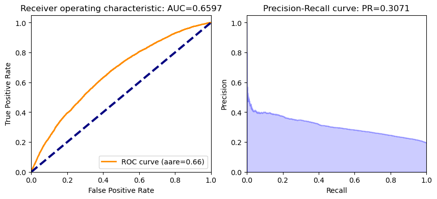

```python
ROC_AUC(rf_v3,test_hex,'loan_default')
```

```python
createGains(rf_v3)
```

```
drf prediction progress: |███████████████████████████████████████████████████████| (done) 100%
```

| decile | count | actual | non_actual | cum_count | cum_actual | cum_non_actual | percent_cum_actual | percent_cum_non_actual | if_random | lift | K_S | gain |
| --- | --- | --- | --- | --- | --- | --- | --- | --- | --- | --- | --- | --- |
| 0 | 3200 | 1203 | 1997 | 3200 | 1203 | 1997 | 0.19 | 0.08 | 622.4 | 1.93 | 11.0 | 37.59 |
| 1 | 3200 | 948 | 2252 | 6400 | 2151 | 4249 | 0.35 | 0.16 | 1244.8 | 1.73 | 19.0 | 33.61 |
| 2 | 3200 | 748 | 2452 | 9600 | 2899 | 6701 | 0.47 | 0.26 | 1867.2 | 1.55 | 21.0 | 30.20 |
| 3 | 3200 | 731 | 2469 | 12800 | 3630 | 9170 | 0.58 | 0.36 | 2489.6 | 1.46 | 22.0 | 28.36 |
| 4 | 3200 | 642 | 2558 | 16000 | 4272 | 11728 | 0.69 | 0.45 | 3112.0 | 1.37 | 24.0 | 26.70 |
| 5 | 3200 | 535 | 2665 | 19200 | 4807 | 14393 | 0.77 | 0.56 | 3734.4 | 1.29 | 21.0 | 25.04 |
| 6 | 3200 | 461 | 2739 | 22400 | 5268 | 17132 | 0.85 | 0.66 | 4356.8 | 1.21 | 19.0 | 23.52 |
| 7 | 3200 | 413 | 2787 | 25600 | 5681 | 19919 | 0.91 | 0.77 | 4979.2 | 1.14 | 14.0 | 22.19 |
| 8 | 3200 | 329 | 2871 | 28800 | 6010 | 22790 | 0.97 | 0.88 | 5601.6 | 1.07 | 9.0 | 20.87 |
| 9 | 3200 | 214 | 2986 | 32000 | 6224 | 25776 | 1.00 | 1.00 | 6224.0 | 1.00 | 0.0 | 19.45 |

> - Using Under-Sampling Techniques

```python
y = df[target]
X = df.drop(target,axis=1)
```

```python
y1_cnt = df[target].sum()
y1_cnt
```

```
15488
```

```python
N = 2
y0_cnt = y1_cnt * N
y0_cnt
```

```
30976
```

```python
#pip install imblearn
```

```python
from imblearn.datasets import make_imbalance
X_rs, y_rs = make_imbalance(X, y,
                            sampling_strategy={1:y1_cnt , 0:  y0_cnt},
                            random_state=123)
X_rs = pd.DataFrame(X_rs)
y_rs = pd.DataFrame(y_rs)
```

```python
y_rs = df[df[target]==1]
X_rs = df[df[target]==0].sample(n=y0_cnt)
smpl = pd.concat([X_rs,y_rs])
smpl_hex = h2o.H2OFrame(smpl)
```

```
Parse progress: |████████████████████████████████████████████████████████████████| (done) 100%
```

```python
rf_v4 = H2ORandomForestEstimator(
        model_id = 'rf_v4',
        ntrees = 50,
        nfolds=10,
        min_rows=10,
        seed=1234)
rf_v4.train(predictors,target,training_frame=smpl_hex)
```

```
drf Model Build progress: |
```

```
██████████████████████████████████████████████████████| (done) 100%
```

```
Model Details
=============
H2ORandomForestEstimator : Distributed Random Forest
Model Key: rf_v4
```

Model Summary:

|  | number_of_trees | number_of_internal_trees | model_size_in_bytes | min_depth | max_depth | mean_depth | min_leaves | max_leaves | mean_leaves |
| --- | --- | --- | --- | --- | --- | --- | --- | --- | --- |
|  | 50.0 | 50.0 | 1387258.0 | 20.0 | 20.0 | 20.0 | 1982.0 | 2099.0 | 2048.62 |

```
ModelMetricsRegression: drf
** Reported on train data. **

MSE: 0.21009002851738065
RMSE: 0.4583557881355712
MAE: 0.41256535055589155
RMSLE: 0.32235450800913673
Mean Residual Deviance: 0.21009002851738065
```

```
ModelMetricsRegression: drf
** Reported on cross-validation data. **

MSE: 0.20785868782246908
RMSE: 0.4559152199943199
MAE: 0.4126689125019681
RMSLE: 0.32052971633245286
Mean Residual Deviance: 0.20785868782246908
```

Cross-Validation Metrics Summary:

|  | mean | sd | cv_1_valid | cv_2_valid | cv_3_valid | cv_4_valid | cv_5_valid | cv_6_valid | cv_7_valid | cv_8_valid | cv_9_valid | cv_10_valid |
| --- | --- | --- | --- | --- | --- | --- | --- | --- | --- | --- | --- | --- |
| mae | 0.4126699 | 0.0028546 | 0.4155091 | 0.4144299 | 0.4099806 | 0.4100317 | 0.4103028 | 0.4120178 | 0.4135687 | 0.4158616 | 0.4164292 | 0.4085673 |
| mean_residual_deviance | 0.2078600 | 0.0027800 | 0.2103731 | 0.2093968 | 0.2054699 | 0.2049028 | 0.2059273 | 0.2074289 | 0.2087528 | 0.2105825 | 0.2120237 | 0.2037422 |
| mse | 0.2078600 | 0.0027800 | 0.2103731 | 0.2093968 | 0.2054699 | 0.2049028 | 0.2059273 | 0.2074289 | 0.2087528 | 0.2105825 | 0.2120237 | 0.2037422 |
| r2 | 0.0645207 | 0.0071396 | 0.0598653 | 0.0714490 | 0.0661856 | 0.0637738 | 0.0705016 | 0.0688190 | 0.0585905 | 0.0547686 | 0.0556567 | 0.0755968 |
| residual_deviance | 0.2078600 | 0.0027800 | 0.2103731 | 0.2093968 | 0.2054699 | 0.2049028 | 0.2059273 | 0.2074289 | 0.2087528 | 0.2105825 | 0.2120237 | 0.2037422 |
| rmse | 0.4559075 | 0.0030492 | 0.4586645 | 0.4575990 | 0.4532879 | 0.4526619 | 0.4537921 | 0.4554436 | 0.4568948 | 0.4588927 | 0.4604603 | 0.4513781 |
| rmsle | 0.3205243 | 0.0016593 | 0.3218028 | 0.3203676 | 0.3193249 | 0.3194209 | 0.3193482 | 0.319947 | 0.3213162 | 0.3227355 | 0.3230616 | 0.3179177 |

Scoring History:

|  | timestamp | duration | number_of_trees | training_rmse | training_mae | training_deviance |
| --- | --- | --- | --- | --- | --- | --- |
|  | 2023-11-19 21:02:58 | 1 min 33.943 sec | 0.0 | nan | nan | nan |
|  | 2023-11-19 21:02:59 | 1 min 34.238 sec | 1.0 | 0.5189482 | 0.4132322 | 0.2693073 |
|  | 2023-11-19 21:02:59 | 1 min 34.501 sec | 2.0 | 0.5128616 | 0.4137816 | 0.2630271 |
|  | 2023-11-19 21:02:59 | 1 min 34.765 sec | 3.0 | 0.5043290 | 0.4116076 | 0.2543477 |
|  | 2023-11-19 21:02:59 | 1 min 35.050 sec | 4.0 | 0.4988811 | 0.4120193 | 0.2488823 |
|  | 2023-11-19 21:03:00 | 1 min 35.334 sec | 5.0 | 0.4933022 | 0.4116101 | 0.2433471 |
|  | 2023-11-19 21:03:00 | 1 min 35.604 sec | 6.0 | 0.4886270 | 0.4112954 | 0.2387564 |
|  | 2023-11-19 21:03:00 | 1 min 35.866 sec | 7.0 | 0.4845218 | 0.4116528 | 0.2347614 |
|  | 2023-11-19 21:03:00 | 1 min 36.123 sec | 8.0 | 0.4816404 | 0.4119047 | 0.2319775 |
|  | 2023-11-19 21:03:01 | 1 min 36.400 sec | 9.0 | 0.4793247 | 0.4124539 | 0.2297521 |
|  | 2023-11-19 21:03:01 | 1 min 36.684 sec | 10.0 | 0.4764101 | 0.4122387 | 0.2269666 |
|  | 2023-11-19 21:03:01 | 1 min 36.963 sec | 11.0 | 0.4745934 | 0.4125039 | 0.2252389 |
|  | 2023-11-19 21:03:02 | 1 min 37.236 sec | 12.0 | 0.4728987 | 0.4126875 | 0.2236332 |
|  | 2023-11-19 21:03:02 | 1 min 37.501 sec | 13.0 | 0.4712582 | 0.4127373 | 0.2220843 |
|  | 2023-11-19 21:03:02 | 1 min 37.746 sec | 14.0 | 0.4701282 | 0.4129488 | 0.2210205 |
|  | 2023-11-19 21:03:06 | 1 min 41.861 sec | 31.0 | 0.4611005 | 0.4128853 | 0.2126136 |
|  | 2023-11-19 21:03:10 | 1 min 45.955 sec | 49.0 | 0.4583807 | 0.4125228 | 0.2101128 |
|  | 2023-11-19 21:03:11 | 1 min 46.185 sec | 50.0 | 0.4583558 | 0.4125654 | 0.2100900 |

Variable Importances:

| variable | relative_importance | scaled_importance | percentage |
| --- | --- | --- | --- |
| MB007 | 12060.1865234 | 1.0 | 0.1043817 |
| AP005 | 10711.8173828 | 0.8881967 | 0.0927115 |
| TD013 | 7886.1044922 | 0.6538957 | 0.0682548 |
| TD009 | 5830.7470703 | 0.4834707 | 0.0504655 |
| AP003 | 5252.1669922 | 0.4354963 | 0.0454578 |
| MB005 | 5231.5332031 | 0.4337854 | 0.0452793 |
| AP001 | 5230.5170898 | 0.4337012 | 0.0452705 |
| TD005 | 4723.0585938 | 0.3916240 | 0.0408784 |
| TD014 | 3926.8310547 | 0.3256028 | 0.0339870 |
| CR019 | 3526.5451660 | 0.2924122 | 0.0305225 |
| --- | --- | --- | --- |
| TD025 | 0.0 | 0.0 | 0.0 |
| TD026 | 0.0 | 0.0 | 0.0 |
| TD027 | 0.0 | 0.0 | 0.0 |
| TD028 | 0.0 | 0.0 | 0.0 |
| TD029 | 0.0 | 0.0 | 0.0 |
| TD044 | 0.0 | 0.0 | 0.0 |
| TD048 | 0.0 | 0.0 | 0.0 |
| TD051 | 0.0 | 0.0 | 0.0 |
| TD054 | 0.0 | 0.0 | 0.0 |
| TD061 | 0.0 | 0.0 | 0.0 |

```
[45 rows x 4 columns]
```

```
[tips]
Use `model.explain()` to inspect the model.
--
Use `h2o.display.toggle_user_tips()` to switch on/off this section.
```

```
drf prediction progress: |███████████████████████████████████████████████████████| (done) 100%

   * ROC curve: The ROC curve plots the true positive rate vs. the false rositive sate

   * The area under the curve (AUC): A value between 0.5 (random) and 1.0 (perfect), measuring the prediction accuracy

   * Recall (R) = The number of true positives / (the number of true positives + the number of false negatives)
```

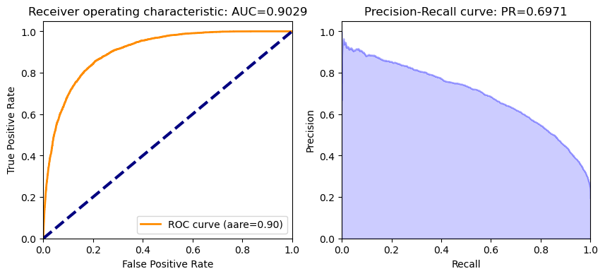

```python
ROC_AUC(rf_v4,test_hex,'loan_default')
```

```python
createGains(rf_v4)
```

```
drf prediction progress: |███████████████████████████████████████████████████████| (done) 100%
```

| decile | count | actual | non_actual | cum_count | cum_actual | cum_non_actual | percent_cum_actual | percent_cum_non_actual | if_random | lift | K_S | gain |
| --- | --- | --- | --- | --- | --- | --- | --- | --- | --- | --- | --- | --- |
| 0 | 3200 | 2476 | 724 | 3200 | 2476 | 724 | 0.40 | 0.03 | 622.4 | 3.98 | 37.0 | 77.38 |
| 1 | 3200 | 1637 | 1563 | 6400 | 4113 | 2287 | 0.66 | 0.09 | 1244.8 | 3.30 | 57.0 | 64.27 |
| 2 | 3200 | 971 | 2229 | 9600 | 5084 | 4516 | 0.82 | 0.18 | 1867.2 | 2.72 | 64.0 | 52.96 |
| 3 | 3200 | 542 | 2658 | 12800 | 5626 | 7174 | 0.90 | 0.28 | 2489.6 | 2.26 | 62.0 | 43.95 |
| 4 | 3200 | 304 | 2896 | 16000 | 5930 | 10070 | 0.95 | 0.39 | 3112.0 | 1.91 | 56.0 | 37.06 |
| 5 | 3200 | 172 | 3028 | 19200 | 6102 | 13098 | 0.98 | 0.51 | 3734.4 | 1.63 | 47.0 | 31.78 |
| 6 | 3200 | 78 | 3122 | 22400 | 6180 | 16220 | 0.99 | 0.63 | 4356.8 | 1.42 | 36.0 | 27.59 |
| 7 | 3200 | 37 | 3163 | 25600 | 6217 | 19383 | 1.00 | 0.75 | 4979.2 | 1.25 | 25.0 | 24.29 |
| 8 | 3200 | 7 | 3193 | 28800 | 6224 | 22576 | 1.00 | 0.88 | 5601.6 | 1.11 | 12.0 | 21.61 |
| 9 | 3200 | 0 | 3200 | 32000 | 6224 | 25776 | 1.00 | 1.00 | 6224.0 | 1.00 | 0.0 | 19.45 |

> - Find the best Hyperparameter using grid search and Drop Useless Variable

> Top 50 `variable_importances` from rf_v4

```python
variable_importances = rf_v4._model_json['output']['variable_importances']['variable'][:50]
scaled_importances = rf_v4._model_json['output']['variable_importances']['scaled_importance'][:50]

# Print the top 10 variable importances along with their scaled importances
for i, (importance, scaled_importance) in enumerate(zip(variable_importances, scaled_importances), start=1):
    print(f"Rank {i}: Variable Importance: {importance}, Scaled Importance: {scaled_importance:.3f}")
```

```
Rank 1: Variable Importance: MB007, Scaled Importance: 1.000
Rank 2: Variable Importance: AP005, Scaled Importance: 0.888
Rank 3: Variable Importance: TD013, Scaled Importance: 0.654
Rank 4: Variable Importance: TD009, Scaled Importance: 0.483
Rank 5: Variable Importance: AP003, Scaled Importance: 0.435
Rank 6: Variable Importance: MB005, Scaled Importance: 0.434
Rank 7: Variable Importance: AP001, Scaled Importance: 0.434
Rank 8: Variable Importance: TD005, Scaled Importance: 0.392
Rank 9: Variable Importance: TD014, Scaled Importance: 0.326
Rank 10: Variable Importance: CR019, Scaled Importance: 0.292
Rank 11: Variable Importance: CR018, Scaled Importance: 0.266
Rank 12: Variable Importance: TD024, Scaled Importance: 0.266
Rank 13: Variable Importance: CR015, Scaled Importance: 0.263
Rank 14: Variable Importance: CR017, Scaled Importance: 0.240
Rank 15: Variable Importance: TD023, Scaled Importance: 0.240
Rank 16: Variable Importance: AP007, Scaled Importance: 0.237
Rank 17: Variable Importance: CR009, Scaled Importance: 0.227
Rank 18: Variable Importance: TD010, Scaled Importance: 0.223
Rank 19: Variable Importance: AP008, Scaled Importance: 0.205
Rank 20: Variable Importance: CR004, Scaled Importance: 0.200
Rank 21: Variable Importance: TD022, Scaled Importance: 0.187
Rank 22: Variable Importance: TD001, Scaled Importance: 0.184
Rank 23: Variable Importance: PA022, Scaled Importance: 0.167
Rank 24: Variable Importance: TD015, Scaled Importance: 0.142
Rank 25: Variable Importance: TD006, Scaled Importance: 0.139
Rank 26: Variable Importance: CR005, Scaled Importance: 0.132
Rank 27: Variable Importance: PA028, Scaled Importance: 0.132
Rank 28: Variable Importance: PA023, Scaled Importance: 0.127
Rank 29: Variable Importance: PA029, Scaled Importance: 0.121
Rank 30: Variable Importance: TD002, Scaled Importance: 0.115
Rank 31: Variable Importance: AP002, Scaled Importance: 0.108
Rank 32: Variable Importance: PA031, Scaled Importance: 0.102
Rank 33: Variable Importance: AP006, Scaled Importance: 0.081
Rank 34: Variable Importance: AP009, Scaled Importance: 0.078
Rank 35: Variable Importance: PA030, Scaled Importance: 0.059
Rank 36: Variable Importance: TD025, Scaled Importance: 0.000
Rank 37: Variable Importance: TD026, Scaled Importance: 0.000
Rank 38: Variable Importance: TD027, Scaled Importance: 0.000
Rank 39: Variable Importance: TD028, Scaled Importance: 0.000
Rank 40: Variable Importance: TD029, Scaled Importance: 0.000
Rank 41: Variable Importance: TD044, Scaled Importance: 0.000
Rank 42: Variable Importance: TD048, Scaled Importance: 0.000
Rank 43: Variable Importance: TD051, Scaled Importance: 0.000
Rank 44: Variable Importance: TD054, Scaled Importance: 0.000
Rank 45: Variable Importance: TD061, Scaled Importance: 0.000
```

> Drop Scaled Importance equal to 0 in rf_v4 model , we will only use top 35 importance variables to build our final model

```python
selected_features = list(rf_v4._model_json['output']['variable_importances']['variable'][:35])
selected_features
```

```
['MB007',
 'AP005',
 'TD013',
 'TD009',
 'AP003',
 'MB005',
 'AP001',
 'TD005',
 'TD014',
 'CR019',
 'CR018',
 'TD024',
 'CR015',
 'CR017',
 'TD023',
 'AP007',
 'CR009',
 'TD010',
 'AP008',
 'CR004',
 'TD022',
 'TD001',
 'PA022',
 'TD015',
 'TD006',
 'CR005',
 'PA028',
 'PA023',
 'PA029',
 'TD002',
 'AP002',
 'PA031',
 'AP006',
 'AP009',
 'PA030']
```

> Tuning the parameter using Grid Search

```python
from h2o.grid.grid_search import H2OGridSearch

# Define the hyperparameters grid
hyperparameters = {
    'ntrees': [25, 30, 35],
    'min_rows': [5]
}

# Create a dictionary to hold the parameters for the H2O model
model_params = {
    'model_id': 'rf_v5',
    'nfolds': 10,
    'seed': 1234
}

# Train your model with grid search
grid_search = H2OGridSearch(model=H2ORandomForestEstimator, hyper_params=hyperparameters)
grid_search.train(x=selected_features, y=target, training_frame=smpl_hex, **model_params)

# Get the best model from the grid search
best_model = grid_search.get_grid()[0]
best_model
```

```
drf Grid Build progress: |███████████████████████████████████████████████████████| (done) 100%
```

```
Model Details
=============
H2ORandomForestEstimator : Distributed Random Forest
Model Key: Grid_DRF_Key_Frame__upload_aa5c4f60467c69777e1fa40c94d8431f.hex_model_python_1700445091020_1_model_3
```

Model Summary:

|  | number_of_trees | number_of_internal_trees | model_size_in_bytes | min_depth | max_depth | mean_depth | min_leaves | max_leaves | mean_leaves |
| --- | --- | --- | --- | --- | --- | --- | --- | --- | --- |
|  | 35.0 | 35.0 | 1607644.0 | 20.0 | 20.0 | 20.0 | 3320.0 | 3556.0 | 3432.0857 |

```
ModelMetricsRegression: drf
** Reported on train data. **

MSE: 0.21552734103764734
RMSE: 0.46424922298012233
MAE: 0.4141380811857418
RMSLE: 0.32696132715082327
Mean Residual Deviance: 0.21552734103764734
```

```
ModelMetricsRegression: drf
** Reported on cross-validation data. **

MSE: 0.20982900405020188
RMSE: 0.45807095962329014
MAE: 0.4131147908062973
RMSLE: 0.32214772028505617
Mean Residual Deviance: 0.20982900405020188
```

Cross-Validation Metrics Summary:

|  | mean | sd | cv_1_valid | cv_2_valid | cv_3_valid | cv_4_valid | cv_5_valid | cv_6_valid | cv_7_valid | cv_8_valid | cv_9_valid | cv_10_valid |
| --- | --- | --- | --- | --- | --- | --- | --- | --- | --- | --- | --- | --- |
| mae | 0.4131171 | 0.0024552 | 0.4143418 | 0.4154029 | 0.4098211 | 0.4108430 | 0.4119935 | 0.4125515 | 0.4142771 | 0.4153848 | 0.4166964 | 0.4098593 |
| mean_residual_deviance | 0.2098315 | 0.0025667 | 0.2111283 | 0.2117838 | 0.2070113 | 0.2073837 | 0.2085012 | 0.2091005 | 0.2111091 | 0.2120670 | 0.2140367 | 0.2061938 |
| mse | 0.2098315 | 0.0025667 | 0.2111283 | 0.2117838 | 0.2070113 | 0.2073837 | 0.2085012 | 0.2091005 | 0.2111091 | 0.2120670 | 0.2140367 | 0.2061938 |
| r2 | 0.0556406 | 0.0063887 | 0.0564905 | 0.0608644 | 0.0591804 | 0.0524384 | 0.0588835 | 0.0613150 | 0.0479644 | 0.0481052 | 0.0466908 | 0.0644738 |
| residual_deviance | 0.2098315 | 0.0025667 | 0.2111283 | 0.2117838 | 0.2070113 | 0.2073837 | 0.2085012 | 0.2091005 | 0.2111091 | 0.2120670 | 0.2140367 | 0.2061938 |
| rmse | 0.4580660 | 0.0028011 | 0.4594870 | 0.4601997 | 0.4549850 | 0.4553940 | 0.4566193 | 0.4572751 | 0.4594661 | 0.4605073 | 0.4626410 | 0.4540856 |
| rmsle | 0.3221447 | 0.0014241 | 0.3223639 | 0.3223294 | 0.3206532 | 0.3213405 | 0.3215161 | 0.3212959 | 0.3233018 | 0.3238289 | 0.3246299 | 0.3201869 |

Scoring History:

|  | timestamp | duration | number_of_trees | training_rmse | training_mae | training_deviance |
| --- | --- | --- | --- | --- | --- | --- |
|  | 2023-11-19 21:07:13 | 4 min 0.775 sec | 0.0 | nan | nan | nan |
|  | 2023-11-19 21:07:14 | 4 min 1.043 sec | 1.0 | 0.5562428 | 0.4200556 | 0.3094061 |
|  | 2023-11-19 21:07:14 | 4 min 1.309 sec | 2.0 | 0.5432691 | 0.4164534 | 0.2951414 |
|  | 2023-11-19 21:07:14 | 4 min 1.568 sec | 3.0 | 0.5330829 | 0.4161751 | 0.2841774 |
|  | 2023-11-19 21:07:14 | 4 min 1.822 sec | 4.0 | 0.5254468 | 0.4165291 | 0.2760944 |
|  | 2023-11-19 21:07:15 | 4 min 2.078 sec | 5.0 | 0.5168618 | 0.4154914 | 0.2671461 |
|  | 2023-11-19 21:07:15 | 4 min 2.343 sec | 6.0 | 0.5108509 | 0.4163459 | 0.2609686 |
|  | 2023-11-19 21:07:15 | 4 min 2.608 sec | 7.0 | 0.5041220 | 0.4160798 | 0.2541390 |
|  | 2023-11-19 21:07:15 | 4 min 2.859 sec | 8.0 | 0.4988765 | 0.4156974 | 0.2488778 |
|  | 2023-11-19 21:07:16 | 4 min 3.129 sec | 9.0 | 0.4940668 | 0.4152955 | 0.2441020 |
|  | 2023-11-19 21:07:16 | 4 min 3.392 sec | 10.0 | 0.4901119 | 0.4151653 | 0.2402097 |
|  | 2023-11-19 21:07:16 | 4 min 3.649 sec | 11.0 | 0.4869518 | 0.4151854 | 0.2371221 |
|  | 2023-11-19 21:07:16 | 4 min 3.906 sec | 12.0 | 0.4838160 | 0.4146695 | 0.2340780 |
|  | 2023-11-19 21:07:17 | 4 min 4.169 sec | 13.0 | 0.4813126 | 0.4143681 | 0.2316618 |
|  | 2023-11-19 21:07:17 | 4 min 4.420 sec | 14.0 | 0.4792686 | 0.4143839 | 0.2296983 |
|  | 2023-11-19 21:07:17 | 4 min 4.667 sec | 15.0 | 0.4775720 | 0.4145255 | 0.2280751 |
|  | 2023-11-19 21:07:21 | 4 min 8.777 sec | 32.0 | 0.4652527 | 0.4142269 | 0.2164601 |
|  | 2023-11-19 21:07:22 | 4 min 9.514 sec | 35.0 | 0.4642492 | 0.4141381 | 0.2155273 |

Variable Importances:

| variable | relative_importance | scaled_importance | percentage |
| --- | --- | --- | --- |
| MB007 | 10472.4531250 | 1.0 | 0.0905063 |
| AP005 | 10369.6669922 | 0.9901851 | 0.0896180 |
| TD013 | 7748.1181641 | 0.7398570 | 0.0669617 |
| MB005 | 5797.1376953 | 0.5535606 | 0.0501007 |
| AP001 | 5531.7670898 | 0.5282208 | 0.0478073 |
| TD009 | 4563.2680664 | 0.4357401 | 0.0394372 |
| CR019 | 3854.6274414 | 0.3680730 | 0.0333129 |
| AP003 | 3815.8994141 | 0.3643749 | 0.0329782 |
| TD005 | 3745.2702637 | 0.3576307 | 0.0323678 |
| TD014 | 3685.9340820 | 0.3519647 | 0.0318550 |
| --- | --- | --- | --- |
| PA023 | 1784.6475830 | 0.1704135 | 0.0154235 |
| PA028 | 1752.6269531 | 0.1673559 | 0.0151468 |
| PA029 | 1747.9805908 | 0.1669122 | 0.0151066 |
| CR005 | 1717.9217529 | 0.1640420 | 0.0148468 |
| PA031 | 1553.6068115 | 0.1483518 | 0.0134268 |
| TD002 | 1536.8566895 | 0.1467523 | 0.0132820 |
| AP002 | 1176.2578125 | 0.1123192 | 0.0101656 |
| AP006 | 1150.8416748 | 0.1098923 | 0.0099459 |
| AP009 | 1033.1810303 | 0.0986570 | 0.0089291 |
| PA030 | 925.1809692 | 0.0883442 | 0.0079957 |

```
[35 rows x 4 columns]
```

```
[tips]
Use `model.explain()` to inspect the model.
--
Use `h2o.display.toggle_user_tips()` to switch on/off this section.
```

> ROC AUC Score in Train Data

```
drf prediction progress: |███████████████████████████████████████████████████████| (done) 100%

   * ROC curve: The ROC curve plots the true positive rate vs. the false rositive sate

   * The area under the curve (AUC): A value between 0.5 (random) and 1.0 (perfect), measuring the prediction accuracy

   * Recall (R) = The number of true positives / (the number of true positives + the number of false negatives)
```

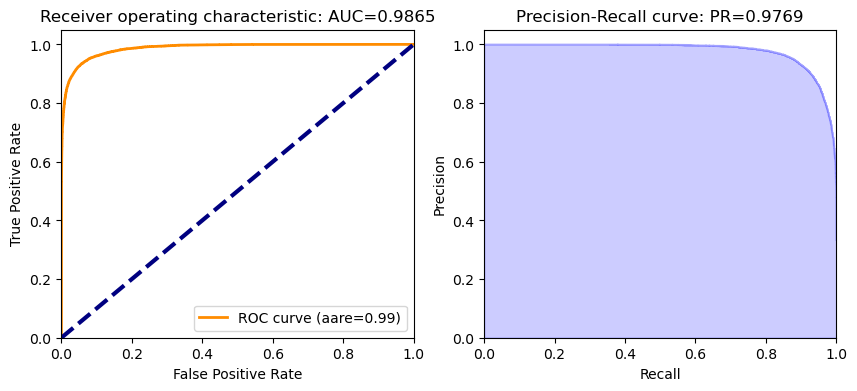

```python
ROC_AUC(best_model,smpl_hex,'loan_default')
```

> ROC AUC Score in Test Data

```
drf prediction progress: |███████████████████████████████████████████████████████| (done) 100%

   * ROC curve: The ROC curve plots the true positive rate vs. the false rositive sate

   * The area under the curve (AUC): A value between 0.5 (random) and 1.0 (perfect), measuring the prediction accuracy

   * Recall (R) = The number of true positives / (the number of true positives + the number of false negatives)
```

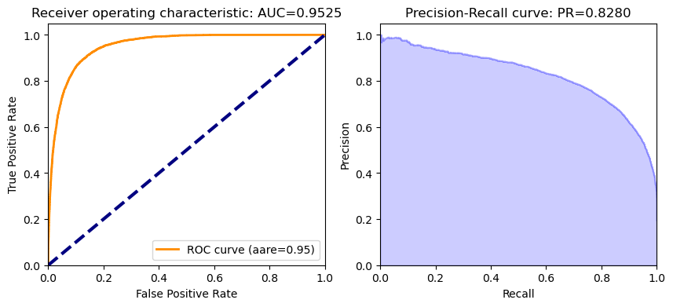

```python
ROC_AUC(best_model,test_hex,'loan_default')
```

```python
createGains(best_model)
```

```
drf prediction progress: |███████████████████████████████████████████████████████| (done) 100%
```

| decile | count | actual | non_actual | cum_count | cum_actual | cum_non_actual | percent_cum_actual | percent_cum_non_actual | if_random | lift | K_S | gain |
| --- | --- | --- | --- | --- | --- | --- | --- | --- | --- | --- | --- | --- |
| 0 | 3200 | 2824 | 376 | 3200 | 2824 | 376 | 0.45 | 0.01 | 622.4 | 4.54 | 44.0 | 88.25 |
| 1 | 3200 | 1973 | 1227 | 6400 | 4797 | 1603 | 0.77 | 0.06 | 1244.8 | 3.85 | 71.0 | 74.95 |
| 2 | 3200 | 912 | 2288 | 9600 | 5709 | 3891 | 0.92 | 0.15 | 1867.2 | 3.06 | 77.0 | 59.47 |
| 3 | 3200 | 335 | 2865 | 12800 | 6044 | 6756 | 0.97 | 0.26 | 2489.6 | 2.43 | 71.0 | 47.22 |
| 4 | 3200 | 129 | 3071 | 16000 | 6173 | 9827 | 0.99 | 0.38 | 3112.0 | 1.98 | 61.0 | 38.58 |
| 5 | 3200 | 41 | 3159 | 19200 | 6214 | 12986 | 1.00 | 0.50 | 3734.4 | 1.66 | 50.0 | 32.36 |
| 6 | 3200 | 9 | 3191 | 22400 | 6223 | 16177 | 1.00 | 0.63 | 4356.8 | 1.43 | 37.0 | 27.78 |
| 7 | 3200 | 1 | 3199 | 25600 | 6224 | 19376 | 1.00 | 0.75 | 4979.2 | 1.25 | 25.0 | 24.31 |
| 8 | 3200 | 0 | 3200 | 28800 | 6224 | 22576 | 1.00 | 0.88 | 5601.6 | 1.11 | 12.0 | 21.61 |
| 9 | 3200 | 0 | 3200 | 32000 | 6224 | 25776 | 1.00 | 1.00 | 6224.0 | 1.00 | 0.0 | 19.45 |

## Section 4: Model Summary & Conclusion

> **Model: rf_v2**
> - Dataset Used: Entire training dataset utilized.
> - Hyperparameters: `ntrees = 500`, `nfolds=10`, `min_rows=100`.
> - ROC Curve: AUC score obtained was `0.6597`, indicating moderate predictive ability.
> - Precision-Recall: Precision-Recall score measured at `0.3071`, reflecting moderate performance in capturing positive cases with high precision.
> - Observation: The model shows moderate predictive performance on the entire dataset but is affected by the highly imbalanced nature of the data.

> **Model: rf_v4 (Using Under-Sampling Techniques)**
> - Technique Used: Under-Sampling to create a more balanced training dataset.
> - Sampling Ratio: Set a ratio of one-third for the fraud cases in the new sample data.
> - Hyperparameters: `ntrees = 50`, `nfolds=10`, `min_rows=10`.
> - ROC Curve: AUC score significantly improved to `0.9029`, showcasing a substantial enhancement in predictive performance.
> - Precision-Recall: Markedly increased to `0.6971`, indicating better precision in identifying positive cases.
> - Observation:
> - Under-Sampling technique significantly boosted the model's ability to learn data patterns, reducing noise and enhancing its capability to detect positive cases.

> **Best Model: best_model**
> - Feature Selection: Utilized the top 50 variable importance from rf_v4.
> - Refinement: Dropped variables with scaled importance < 5%, resulting in a final set of 35 features.
> - Hyperparameter Tuning Using Search Grid Approach: Employed a search grid strategy to fine-tune hyperparameters for optimal model performance.
> - Parameter Range: Explored `'ntrees': [25, 30, 35]` and `'min_rows': [5]`.
> - Cross-Validation: Implemented 10-fold cross-validation to prevent overfitting during hyperparameter tuning.
> - Optimal Hyperparameters: Determined `'ntrees' = 35`, `'min_rows': [5]` as the best combination.
> - Performance: Achieved an average RMSE of `0.458` in cross-validation data, indicating good predictive ability.
- **Model Evaluation**:
- Training Data:
  - ROC AUC: Impressive score of `0.9865`, nearly perfect in distinguishing between normal and outlier classes.
  - Precision-Recall Rate: `0.9769`, showing a high rate of correctly identifying positive cases.
- Test Data:
  - ROC AUC: Stable performance with a score of `0.9525`, indicating robustness and consistency.
  - Precision-Recall Rate: Significant improvement to `0.828` compared to rf_v4, showing enhanced ability to detect true positive cases out of total predictions.

> **Final Thoughts:**
> - The journey from data preparation to model optimization showcased the significance of thoughtful feature selection, effective handling of imbalanced data, and meticulous hyperparameter tuning in enhancing model performance. The `rf_best` model represents a robust and highly effective predictive tool, laying the groundwork for future advancements in predictive analytics within supervised learning in probability of default domain.
- Model Enhancement:
  - Iterative improvements in feature selection, hyperparameter tuning, and sampling techniques significantly enhanced model performance.
- Continuous Refinement:
  - Ongoing exploration of advanced techniques, ensemble methods, and continuous model monitoring is recommended to further enhance accuracy and reliability.